# W3cubDocs

/Qt 5.15

# QRectF Class

The QRectF class defines a rectangle in the plane using floating point precision. More...

| Header: | #include <QRectF> |
| --- | --- |
| qmake: | QT += core |

- [List of all members, including inherited members](https://doc.qt.io/qt-5.15/qrectf-members.html)
- [Obsolete members](https://doc.qt.io/qt-5.15/qrectf-obsolete.html)

**Note:** All functions in this class are reentrant.

## Public Functions

|  | **QRectF**(const QRect &*rectangle*) |
| --- | --- |
|  | **QRectF**(qreal *x*, qreal *y*, qreal *width*, qreal *height*) |
|  | **QRectF**(const QPointF &*topLeft*, const QPointF &*bottomRight*) |
|  | **QRectF**(const QPointF &*topLeft*, const QSizeF &*size*) |
|  | **QRectF**() |
| void | **adjust**(qreal *dx1*, qreal *dy1*, qreal *dx2*, qreal *dy2*) |
| QRectF | **adjusted**(qreal *dx1*, qreal *dy1*, qreal *dx2*, qreal *dy2*) const |
| qreal | **bottom**() const |
| QPointF | **bottomLeft**() const |
| QPointF | **bottomRight**() const |
| QPointF | **center**() const |
| bool | **contains**(const QPointF &*point*) const |
| bool | **contains**(const QRectF &*rectangle*) const |
| bool | **contains**(qreal *x*, qreal *y*) const |
| void | **getCoords**(qreal **x1*, qreal **y1*, qreal **x2*, qreal **y2*) const |
| void | **getRect**(qreal **x*, qreal **y*, qreal **width*, qreal **height*) const |
| qreal | **height**() const |
| QRectF | **intersected**(const QRectF &*rectangle*) const |
| bool | **intersects**(const QRectF &*rectangle*) const |
| bool | **isEmpty**() const |
| bool | **isNull**() const |
| bool | **isValid**() const |
| qreal | **left**() const |
| QRectF | **marginsAdded**(const QMarginsF &*margins*) const |
| QRectF | **marginsRemoved**(const QMarginsF &*margins*) const |
| void | **moveBottom**(qreal *y*) |
| void | **moveBottomLeft**(const QPointF &*position*) |
| void | **moveBottomRight**(const QPointF &*position*) |
| void | **moveCenter**(const QPointF &*position*) |
| void | **moveLeft**(qreal *x*) |
| void | **moveRight**(qreal *x*) |
| void | **moveTo**(qreal *x*, qreal *y*) |
| void | **moveTo**(const QPointF &*position*) |
| void | **moveTop**(qreal *y*) |
| void | **moveTopLeft**(const QPointF &*position*) |
| void | **moveTopRight**(const QPointF &*position*) |
| QRectF | **normalized**() const |
| qreal | **right**() const |
| void | **setBottom**(qreal *y*) |
| void | **setBottomLeft**(const QPointF &*position*) |
| void | **setBottomRight**(const QPointF &*position*) |
| void | **setCoords**(qreal *x1*, qreal *y1*, qreal *x2*, qreal *y2*) |
| void | **setHeight**(qreal *height*) |
| void | **setLeft**(qreal *x*) |
| void | **setRect**(qreal *x*, qreal *y*, qreal *width*, qreal *height*) |
| void | **setRight**(qreal *x*) |
| void | **setSize**(const QSizeF &*size*) |
| void | **setTop**(qreal *y*) |
| void | **setTopLeft**(const QPointF &*position*) |
| void | **setTopRight**(const QPointF &*position*) |
| void | **setWidth**(qreal *width*) |
| void | **setX**(qreal *x*) |
| void | **setY**(qreal *y*) |
| QSizeF | **size**() const |
| QRect | **toAlignedRect**() const |
| CGRect | **toCGRect**() const |
| QRect | **toRect**() const |
| qreal | **top**() const |
| QPointF | **topLeft**() const |
| QPointF | **topRight**() const |
| void | **translate**(qreal *dx*, qreal *dy*) |
| void | **translate**(const QPointF &*offset*) |
| QRectF | **translated**(qreal *dx*, qreal *dy*) const |
| QRectF | **translated**(const QPointF &*offset*) const |
| QRectF | **transposed**() const |
| QRectF | **united**(const QRectF &*rectangle*) const |
| qreal | **width**() const |
| qreal | **x**() const |
| qreal | **y**() const |
| QRectF | **operator&**(const QRectF &*rectangle*) const |
| QRectF & | **operator&=**(const QRectF &*rectangle*) |
| QRectF & | **operator+=**(const QMarginsF &*margins*) |
| QRectF & | **operator-=**(const QMarginsF &*margins*) |
| QRectF | **operator\|**(const QRectF &*rectangle*) const |
| QRectF & | **operator\|=**(const QRectF &*rectangle*) |

## Static Public Members

| QRectF | **fromCGRect**(CGRect *rect*) |
| --- | --- |

## Related Non-Members

| bool | **operator!=**(const QRectF &*r1*, const QRectF &*r2*) |
| --- | --- |
| QRectF | **operator+**(const QRectF &*lhs*, const QMarginsF &*rhs*) |
| QRectF | **operator+**(const QMarginsF &*lhs*, const QRectF &*rhs*) |
| QRectF | **operator-**(const QRectF &*lhs*, const QMarginsF &*rhs*) |
| QDataStream & | **operator<<**(QDataStream &*stream*, const QRectF &*rectangle*) |
| bool | **operator==**(const QRectF &*r1*, const QRectF &*r2*) |
| QDataStream & | **operator>>**(QDataStream &*stream*, QRectF &*rectangle*) |

## Detailed Description

A rectangle is normally expressed as a top-left corner and a size. The size (width and height) of a QRectF is always equivalent to the mathematical rectangle that forms the basis for its rendering.

A QRectF can be constructed with a set of left, top, width and height coordinates, or from a QPointF and a QSizeF. The following code creates two identical rectangles.

```
QRectF r1(100.0, 200.1, 11.2, 16.3);
QRectF r2(QPointF(100.0, 200.1), QSizeF(11.2, 16.3));
```

There is also a third constructor creating a QRectF from a QRect, and a corresponding toRect() function that returns a QRect object based on the values of this rectangle (note that the coordinates in the returned rectangle are rounded to the nearest integer).

The QRectF class provides a collection of functions that return the various rectangle coordinates, and enable manipulation of these. QRectF also provides functions to move the rectangle relative to the various coordinates. In addition there is a moveTo() function that moves the rectangle, leaving its top left corner at the given coordinates. Alternatively, the translate() function moves the rectangle the given offset relative to the current position, and the translated() function returns a translated copy of this rectangle.

The size() function returns the rectangle's dimensions as a QSizeF. The dimensions can also be retrieved separately using the width() and height() functions. To manipulate the dimensions use the setSize(), setWidth() or setHeight() functions. Alternatively, the size can be changed by applying either of the functions setting the rectangle coordinates, for example, setBottom() or setRight().

The contains() function tells whether a given point is inside the rectangle or not, and the intersects() function returns `true` if this rectangle intersects with a given rectangle (otherwise false). The QRectF class also provides the intersected() function which returns the intersection rectangle, and the united() function which returns the rectangle that encloses the given rectangle and this:

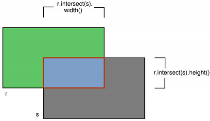

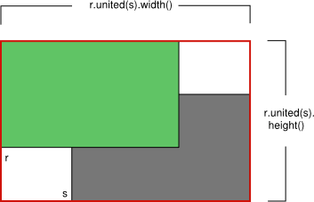

intersected()

united()

The isEmpty() function returns `true` if the rectangle's width or height is less than, or equal to, 0. Note that an empty rectangle is not valid: The isValid() function returns `true` if both width and height is larger than 0. A null rectangle (isNull() == true) on the other hand, has both width and height set to 0.

Note that due to the way QRect and QRectF are defined, an empty QRectF is defined in essentially the same way as QRect.

Finally, QRectF objects can be streamed as well as compared.

### Rendering

When using an anti-aliased painter, the boundary line of a QRectF will be rendered symmetrically on both sides of the mathematical rectangle's boundary line. But when using an aliased painter (the default) other rules apply.

Then, when rendering with a one pixel wide pen the QRectF's boundary line will be rendered to the right and below the mathematical rectangle's boundary line.

When rendering with a two pixels wide pen the boundary line will be split in the middle by the mathematical rectangle. This will be the case whenever the pen is set to an even number of pixels, while rendering with a pen with an odd number of pixels, the spare pixel will be rendered to the right and below the mathematical rectangle as in the one pixel case.

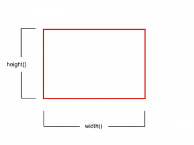

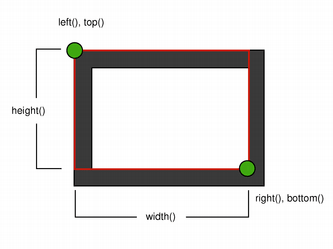

Logical representation

One pixel wide pen

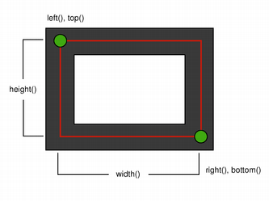

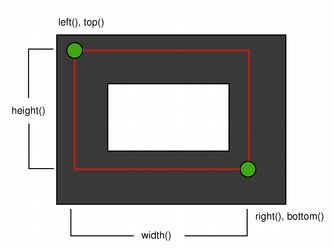

Two pixel wide pen

Three pixel wide pen

### Coordinates

The QRectF class provides a collection of functions that return the various rectangle coordinates, and enable manipulation of these. QRectF also provides functions to move the rectangle relative to the various coordinates.

For example: the bottom(), setBottom() and moveBottom() functions: bottom() returns the y-coordinate of the rectangle's bottom edge, setBottom() sets the bottom edge of the rectangle to the given y coordinate (it may change the height, but will never change the rectangle's top edge) and moveBottom() moves the entire rectangle vertically, leaving the rectangle's bottom edge at the given y coordinate and its size unchanged.

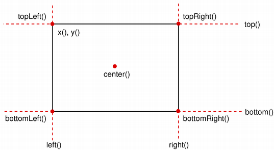

It is also possible to add offsets to this rectangle's coordinates using the adjust() function, as well as retrieve a new rectangle based on adjustments of the original one using the adjusted() function. If either of the width and height is negative, use the normalized() function to retrieve a rectangle where the corners are swapped.

In addition, QRectF provides the getCoords() function which extracts the position of the rectangle's top-left and bottom-right corner, and the getRect() function which extracts the rectangle's top-left corner, width and height. Use the setCoords() and setRect() function to manipulate the rectangle's coordinates and dimensions in one go.

**See also** QRect and QRegion.

## Member Function Documentation

### QRectF::QRectF(const QRect &*rectangle*)

Constructs a QRectF rectangle from the given QRect *rectangle*.

**See also** toRect().

### QRectF::QRectF(qreal *x*, qreal *y*, qreal *width*, qreal *height*)

Constructs a rectangle with (*x*, *y*) as its top-left corner and the given *width* and *height*.

**See also** setRect().

### QRectF::QRectF(const QPointF &*topLeft*, const QPointF &*bottomRight*)

Constructs a rectangle with the given *topLeft* and *bottomRight* corners.

This function was introduced in Qt 4.3.

**See also** setTopLeft() and setBottomRight().

### QRectF::QRectF(const QPointF &*topLeft*, const QSizeF &*size*)

Constructs a rectangle with the given *topLeft* corner and the given *size*.

**See also** setTopLeft() and setSize().

### QRectF::QRectF()

Constructs a null rectangle.

**See also** isNull().

### void QRectF::adjust(qreal *dx1*, qreal *dy1*, qreal *dx2*, qreal *dy2*)

Adds *dx1*, *dy1*, *dx2* and *dy2* respectively to the existing coordinates of the rectangle.

**See also** adjusted() and setRect().

### QRectF QRectF::adjusted(qreal *dx1*, qreal *dy1*, qreal *dx2*, qreal *dy2*) const

Returns a new rectangle with *dx1*, *dy1*, *dx2* and *dy2* added respectively to the existing coordinates of this rectangle.

**See also** adjust().

### qreal QRectF::bottom() const

Returns the y-coordinate of the rectangle's bottom edge.

**See also** setBottom(), bottomLeft(), and bottomRight().

### QPointF QRectF::bottomLeft() const

Returns the position of the rectangle's bottom-left corner.

**See also** setBottomLeft(), bottom(), and left().

### QPointF QRectF::bottomRight() const

Returns the position of the rectangle's bottom-right corner.

**See also** setBottomRight(), bottom(), and right().

### QPointF QRectF::center() const

Returns the center point of the rectangle.

**See also** moveCenter().

### bool QRectF::contains(const QPointF &*point*) const

Returns `true` if the given *point* is inside or on the edge of the rectangle; otherwise returns `false`.

**See also** intersects().

### bool QRectF::contains(const QRectF &*rectangle*) const

This is an overloaded function.

Returns `true` if the given *rectangle* is inside this rectangle; otherwise returns `false`.

### bool QRectF::contains(qreal *x*, qreal *y*) const

This is an overloaded function.

Returns `true` if the point (*x*, *y*) is inside or on the edge of the rectangle; otherwise returns `false`.

### `[static]`QRectF QRectF::fromCGRect(CGRect *rect*)

Creates a QRectF from CGRect *rect*.

This function was introduced in Qt 5.8.

**See also** toCGRect().

### void QRectF::getCoords(qreal **x1*, qreal **y1*, qreal **x2*, qreal **y2*) const

Extracts the position of the rectangle's top-left corner to **x1* and **y1*, and the position of the bottom-right corner to **x2* and **y2*.

**See also** setCoords() and getRect().

### void QRectF::getRect(qreal **x*, qreal **y*, qreal **width*, qreal **height*) const

Extracts the position of the rectangle's top-left corner to **x* and **y*, and its dimensions to **width* and **height*.

**See also** setRect() and getCoords().

### qreal QRectF::height() const

Returns the height of the rectangle.

**See also** setHeight(), width(), and size().

### QRectF QRectF::intersected(const QRectF &*rectangle*) const

Returns the intersection of this rectangle and the given *rectangle*. Note that `r.intersected(s)` is equivalent to `r & s`.

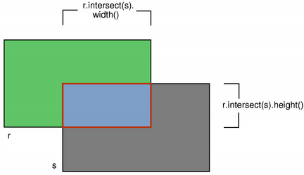

This function was introduced in Qt 4.2.

**See also** intersects(), united(), and operator&=().

### bool QRectF::intersects(const QRectF &*rectangle*) const

Returns `true` if this rectangle intersects with the given *rectangle* (i.e. there is a non-empty area of overlap between them), otherwise returns `false`.

The intersection rectangle can be retrieved using the intersected() function.

**See also** contains().

### bool QRectF::isEmpty() const

Returns `true` if the rectangle is empty, otherwise returns `false`.

An empty rectangle has width() <= 0 or height() <= 0. An empty rectangle is not valid (i.e., isEmpty() == !isValid()).

Use the normalized() function to retrieve a rectangle where the corners are swapped.

**See also** isNull(), isValid(), and normalized().

### bool QRectF::isNull() const

Returns `true` if the rectangle is a null rectangle, otherwise returns `false`.

A null rectangle has both the width and the height set to 0. A null rectangle is also empty, and hence not valid.

**See also** isEmpty() and isValid().

### bool QRectF::isValid() const

Returns `true` if the rectangle is valid, otherwise returns `false`.

A valid rectangle has a width() > 0 and height() > 0. Note that non-trivial operations like intersections are not defined for invalid rectangles. A valid rectangle is not empty (i.e., isValid() == !isEmpty()).

**See also** isNull(), isEmpty(), and normalized().

### qreal QRectF::left() const

Returns the x-coordinate of the rectangle's left edge. Equivalent to x().

**See also** setLeft(), topLeft(), and bottomLeft().

### QRectF QRectF::marginsAdded(const QMarginsF &*margins*) const

Returns a rectangle grown by the *margins*.

This function was introduced in Qt 5.3.

**See also** operator+=(), marginsRemoved(), and operator-=().

### QRectF QRectF::marginsRemoved(const QMarginsF &*margins*) const

Removes the *margins* from the rectangle, shrinking it.

This function was introduced in Qt 5.3.

**See also** marginsAdded(), operator+=(), and operator-=().

### void QRectF::moveBottom(qreal *y*)

Moves the rectangle vertically, leaving the rectangle's bottom edge at the given *y* coordinate. The rectangle's size is unchanged.

**See also** bottom(), setBottom(), and moveTop().

### void QRectF::moveBottomLeft(const QPointF &*position*)

Moves the rectangle, leaving the bottom-left corner at the given *position*. The rectangle's size is unchanged.

**See also** setBottomLeft(), moveBottom(), and moveLeft().

### void QRectF::moveBottomRight(const QPointF &*position*)

Moves the rectangle, leaving the bottom-right corner at the given *position*. The rectangle's size is unchanged.

**See also** setBottomRight(), moveBottom(), and moveRight().

### void QRectF::moveCenter(const QPointF &*position*)

Moves the rectangle, leaving the center point at the given *position*. The rectangle's size is unchanged.

**See also** center().

### void QRectF::moveLeft(qreal *x*)

Moves the rectangle horizontally, leaving the rectangle's left edge at the given *x* coordinate. The rectangle's size is unchanged.

**See also** left(), setLeft(), and moveRight().

### void QRectF::moveRight(qreal *x*)

Moves the rectangle horizontally, leaving the rectangle's right edge at the given *x* coordinate. The rectangle's size is unchanged.

**See also** right(), setRight(), and moveLeft().

### void QRectF::moveTo(qreal *x*, qreal *y*)

Moves the rectangle, leaving the top-left corner at the given position (*x*, *y*). The rectangle's size is unchanged.

**See also** translate() and moveTopLeft().

### void QRectF::moveTo(const QPointF &*position*)

This is an overloaded function.

Moves the rectangle, leaving the top-left corner at the given *position*.

### void QRectF::moveTop(qreal *y*)

Moves the rectangle vertically, leaving the rectangle's top line at the given *y* coordinate. The rectangle's size is unchanged.

**See also** top(), setTop(), and moveBottom().

### void QRectF::moveTopLeft(const QPointF &*position*)

Moves the rectangle, leaving the top-left corner at the given *position*. The rectangle's size is unchanged.

**See also** setTopLeft(), moveTop(), and moveLeft().

### void QRectF::moveTopRight(const QPointF &*position*)

Moves the rectangle, leaving the top-right corner at the given *position*. The rectangle's size is unchanged.

**See also** setTopRight(), moveTop(), and moveRight().

### QRectF QRectF::normalized() const

Returns a normalized rectangle; i.e., a rectangle that has a non-negative width and height.

If width() < 0 the function swaps the left and right corners, and it swaps the top and bottom corners if height() < 0.

**See also** isValid() and isEmpty().

### qreal QRectF::right() const

Returns the x-coordinate of the rectangle's right edge.

**See also** setRight(), topRight(), and bottomRight().

### void QRectF::setBottom(qreal *y*)

Sets the bottom edge of the rectangle to the given *y* coordinate. May change the height, but will never change the top edge of the rectangle.

**See also** bottom() and moveBottom().

### void QRectF::setBottomLeft(const QPointF &*position*)

Set the bottom-left corner of the rectangle to the given *position*. May change the size, but will never change the top-right corner of the rectangle.

**See also** bottomLeft() and moveBottomLeft().

### void QRectF::setBottomRight(const QPointF &*position*)

Set the bottom-right corner of the rectangle to the given *position*. May change the size, but will never change the top-left corner of the rectangle.

**See also** bottomRight() and moveBottomRight().

### void QRectF::setCoords(qreal *x1*, qreal *y1*, qreal *x2*, qreal *y2*)

Sets the coordinates of the rectangle's top-left corner to (*x1*, *y1*), and the coordinates of its bottom-right corner to (*x2*, *y2*).

**See also** getCoords() and setRect().

### void QRectF::setHeight(qreal *height*)

Sets the height of the rectangle to the given *height*. The bottom edge is changed, but not the top one.

**See also** height() and setSize().

### void QRectF::setLeft(qreal *x*)

Sets the left edge of the rectangle to the given *x* coordinate. May change the width, but will never change the right edge of the rectangle.

Equivalent to setX().

**See also** left() and moveLeft().

### void QRectF::setRect(qreal *x*, qreal *y*, qreal *width*, qreal *height*)

Sets the coordinates of the rectangle's top-left corner to (*x*, *y*), and its size to the given *width* and *height*.

**See also** getRect() and setCoords().

### void QRectF::setRight(qreal *x*)

Sets the right edge of the rectangle to the given *x* coordinate. May change the width, but will never change the left edge of the rectangle.

**See also** right() and moveRight().

### void QRectF::setSize(const QSizeF &*size*)

Sets the size of the rectangle to the given *size*. The top-left corner is not moved.

**See also** size(), setWidth(), and setHeight().

### void QRectF::setTop(qreal *y*)

Sets the top edge of the rectangle to the given *y* coordinate. May change the height, but will never change the bottom edge of the rectangle.

Equivalent to setY().

**See also** top() and moveTop().

### void QRectF::setTopLeft(const QPointF &*position*)

Set the top-left corner of the rectangle to the given *position*. May change the size, but will never change the bottom-right corner of the rectangle.

**See also** topLeft() and moveTopLeft().

### void QRectF::setTopRight(const QPointF &*position*)

Set the top-right corner of the rectangle to the given *position*. May change the size, but will never change the bottom-left corner of the rectangle.

**See also** topRight() and moveTopRight().

### void QRectF::setWidth(qreal *width*)

Sets the width of the rectangle to the given *width*. The right edge is changed, but not the left one.

**See also** width() and setSize().

### void QRectF::setX(qreal *x*)

Sets the left edge of the rectangle to the given *x* coordinate. May change the width, but will never change the right edge of the rectangle.

Equivalent to setLeft().

**See also** x(), setY(), and setTopLeft().

### void QRectF::setY(qreal *y*)

Sets the top edge of the rectangle to the given *y* coordinate. May change the height, but will never change the bottom edge of the rectangle.

Equivalent to setTop().

**See also** y(), setX(), and setTopLeft().

### QSizeF QRectF::size() const

Returns the size of the rectangle.

**See also** setSize(), width(), and height().

### QRect QRectF::toAlignedRect() const

Returns a QRect based on the values of this rectangle that is the smallest possible integer rectangle that completely contains this rectangle.

This function was introduced in Qt 4.3.

**See also** toRect().

### CGRect QRectF::toCGRect() const

Creates a CGRect from a QRectF.

This function was introduced in Qt 5.8.

**See also** fromCGRect().

### QRect QRectF::toRect() const

Returns a QRect based on the values of this rectangle. Note that the coordinates in the returned rectangle are rounded to the nearest integer.

**See also** QRectF() and toAlignedRect().

### qreal QRectF::top() const

Returns the y-coordinate of the rectangle's top edge. Equivalent to y().

**See also** setTop(), topLeft(), and topRight().

### QPointF QRectF::topLeft() const

Returns the position of the rectangle's top-left corner.

**See also** setTopLeft(), top(), and left().

### QPointF QRectF::topRight() const

Returns the position of the rectangle's top-right corner.

**See also** setTopRight(), top(), and right().

### void QRectF::translate(qreal *dx*, qreal *dy*)

Moves the rectangle *dx* along the x-axis and *dy* along the y-axis, relative to the current position. Positive values move the rectangle to the right and downwards.

**See also** moveTopLeft(), moveTo(), and translated().

### void QRectF::translate(const QPointF &*offset*)

This is an overloaded function.

Moves the rectangle *offset*.x() along the x axis and *offset*.y() along the y axis, relative to the current position.

### QRectF QRectF::translated(qreal *dx*, qreal *dy*) const

Returns a copy of the rectangle that is translated *dx* along the x axis and *dy* along the y axis, relative to the current position. Positive values move the rectangle to the right and down.

**See also** translate().

### QRectF QRectF::translated(const QPointF &*offset*) const

This is an overloaded function.

Returns a copy of the rectangle that is translated *offset*.x() along the x axis and *offset*.y() along the y axis, relative to the current position.

### QRectF QRectF::transposed() const

Returns a copy of the rectangle that has its width and height exchanged:

```
QRectF r = {1.5, 5.1, 4.2, 2.4};
r = r.transposed(); // r == {1.5, 5.1, 2.4, 4.2}
```

This function was introduced in Qt 5.7.

**See also** QSizeF::transposed().

### QRectF QRectF::united(const QRectF &*rectangle*) const

Returns the bounding rectangle of this rectangle and the given *rectangle*.

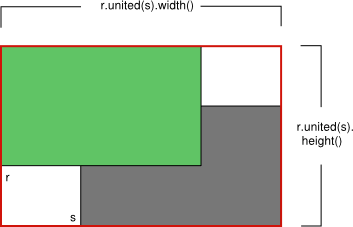

This function was introduced in Qt 4.2.

**See also** intersected().

### qreal QRectF::width() const

Returns the width of the rectangle.

**See also** setWidth(), height(), and size().

### qreal QRectF::x() const

Returns the x-coordinate of the rectangle's left edge. Equivalent to left().

**See also** setX(), y(), and topLeft().

### qreal QRectF::y() const

Returns the y-coordinate of the rectangle's top edge. Equivalent to top().

**See also** setY(), x(), and topLeft().

### QRectF QRectF::operator&(const QRectF &*rectangle*) const

Returns the intersection of this rectangle and the given *rectangle*. Returns an empty rectangle if there is no intersection.

**See also** operator&=() and intersected().

### QRectF &QRectF::operator&=(const QRectF &*rectangle*)

Intersects this rectangle with the given *rectangle*.

**See also** intersected() and operator|=().

### QRectF &QRectF::operator+=(const QMarginsF &*margins*)

Adds the *margins* to the rectangle, growing it.

This function was introduced in Qt 5.3.

**See also** marginsAdded(), marginsRemoved(), and operator-=().

### QRectF &QRectF::operator-=(const QMarginsF &*margins*)

Returns a rectangle shrunk by the *margins*.

This function was introduced in Qt 5.3.

**See also** marginsRemoved(), operator+=(), and marginsAdded().

### QRectF QRectF::operator|(const QRectF &*rectangle*) const

Returns the bounding rectangle of this rectangle and the given *rectangle*.

**See also** united() and operator|=().

### QRectF &QRectF::operator|=(const QRectF &*rectangle*)

Unites this rectangle with the given *rectangle*.

**See also** united() and operator|().

## Related Non-Members

### bool operator!=(const QRectF &*r1*, const QRectF &*r2*)

Returns `true` if the rectangles *r1* and *r2* are different, otherwise returns `false`.

### QRectF operator+(const QRectF &*lhs*, const QMarginsF &*rhs*)

Returns the *lhs* rectangle grown by the *rhs* margins.

This function was introduced in Qt 5.3.

### QRectF operator+(const QMarginsF &*lhs*, const QRectF &*rhs*)

This is an overloaded function.

Returns the *lhs* rectangle grown by the *rhs* margins.

This function was introduced in Qt 5.3.

### QRectF operator-(const QRectF &*lhs*, const QMarginsF &*rhs*)

Returns the *lhs* rectangle shrunk by the *rhs* margins.

This function was introduced in Qt 5.3.

### QDataStream &operator<<(QDataStream &*stream*, const QRectF &*rectangle*)

Writes the *rectangle* to the *stream*, and returns a reference to the stream.

**See also** Serializing Qt Data Types.

### bool operator==(const QRectF &*r1*, const QRectF &*r2*)

Returns `true` if the rectangles *r1* and *r2* are equal, otherwise returns `false`.

### QDataStream &operator>>(QDataStream &*stream*, QRectF &*rectangle*)

Reads a *rectangle* from the *stream*, and returns a reference to the stream.

**See also** Serializing Qt Data Types.

© The Qt Company Ltd  
Licensed under the GNU Free Documentation License, Version 1.3.  
https://doc.qt.io/qt-5.15/qrectf.html